# XGBoost Algorithm

INFO 523

Student - [Gayathri Renganathan, Mohit Rakesh Taparia]

iSchool

Instructor - Cristian Román-Palacios

School of Information, University of Arizona, Tucson, AZ

```r
library(readxl)
library(dplyr)
library(caret)
library(xgboost)
library(ggplot2)
library(GGally)
library(fastDummies)
library(corrplot)
library(pROC)
library(SHAPforxgboost)
```

**The case study references the Telecom customer churn dataset** https://archive.ics.uci.edu/dataset/563/iranian+churn+dataset

```r
file_path <- "Data/Customer Churn.csv"
customerInfo <- read.csv(file_path,  sep = ",", header = TRUE)
```

```r
head(customerInfo,10)
```

```
##    Call..Failure Complains Subscription..Length Charge..Amount Seconds.of.Use
## 1              8         0                   38              0           4370
## 2              0         0                   39              0            318
## 3             10         0                   37              0           2453
## 4             10         0                   38              0           4198
## 5              3         0                   38              0           2393
## 6             11         0                   38              1           3775
## 7              4         0                   38              0           2360
## 8             13         0                   37              2           9115
## 9              7         0                   38              0          13773
## 10             7         0                   38              1           4515
##    Frequency.of.use Frequency.of.SMS Distinct.Called.Numbers Age.Group
## 1                71                5                      17         3
## 2                 5                7                       4         2
## 3                60              359                      24         3
```

[output cut: 18 more lines]

```r
summary(customerInfo)
```

```
##  Call..Failure      Complains       Subscription..Length Charge..Amount
##  Min.   : 0.000   Min.   :0.00000   Min.   : 3.00        Min.   : 0.0000
##  1st Qu.: 1.000   1st Qu.:0.00000   1st Qu.:30.00        1st Qu.: 0.0000
##  Median : 6.000   Median :0.00000   Median :35.00        Median : 0.0000
##  Mean   : 7.628   Mean   :0.07651   Mean   :32.54        Mean   : 0.9429
##  3rd Qu.:12.000   3rd Qu.:0.00000   3rd Qu.:38.00        3rd Qu.: 1.0000
##  Max.   :36.000   Max.   :1.00000   Max.   :47.00        Max.   :10.0000
##  Seconds.of.Use  Frequency.of.use Frequency.of.SMS Distinct.Called.Numbers
##  Min.   :    0   Min.   :  0.00   Min.   :  0.00   Min.   : 0.00
##  1st Qu.: 1391   1st Qu.: 27.00   1st Qu.:  6.00   1st Qu.:10.00
##  Median : 2990   Median : 54.00   Median : 21.00   Median :21.00
##  Mean   : 4472   Mean   : 69.46   Mean   : 73.17   Mean   :23.51
##  3rd Qu.: 6478   3rd Qu.: 95.00   3rd Qu.: 87.00   3rd Qu.:34.00
##  Max.   :17090   Max.   :255.00   Max.   :522.00   Max.   :97.00
##    Age.Group      Tariff.Plan        Status           Age     Customer.Value
##  Min.   :1.000   Min.   :1.000   Min.   :1.000   Min.   :15   Min.   :   0.0
##  1st Qu.:2.000   1st Qu.:1.000   1st Qu.:1.000   1st Qu.:25   1st Qu.: 113.8
##  Median :3.000   Median :1.000   Median :1.000   Median :30   Median : 228.5
##  Mean   :2.826   Mean   :1.078   Mean   :1.248   Mean   :31   Mean   : 471.0
##  3rd Qu.:3.000   3rd Qu.:1.000   3rd Qu.:1.000   3rd Qu.:30   3rd Qu.: 788.4
##  Max.   :5.000   Max.   :2.000   Max.   :2.000   Max.   :55   Max.   :2165.3
##      Churn
##  Min.   :0.0000
##  1st Qu.:0.0000
##  Median :0.0000
##  Mean   :0.1571
##  3rd Qu.:0.0000
##  Max.   :1.0000
```

### **Checking for null Values**

```r
sum(is.na(customerInfo))
```

```
## [1] 0
```

### **Count of Number of customer who got churned or not**

```r
customerInfo %>% group_by(Churn) %>% summarise(n=n()) %>% arrange(desc(n))
```

```
## # A tibble: 2 × 2
##   Churn     n
##   <int> <int>
## 1     0  2655
## 2     1   495
```

#### Plotting churn count in the dataset.

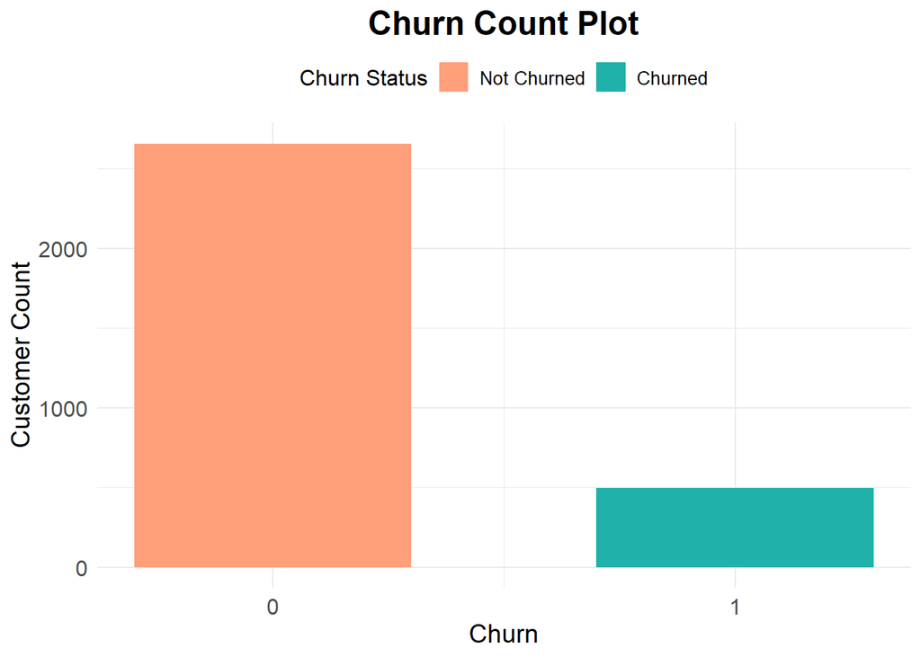

```r
ggplot(customerInfo, aes(Churn, fill = factor(Churn))) +
  geom_bar(width = 0.6) +
  scale_fill_manual(values = c("#FFA07A", "#20B2AA"),
        labels = c("0" = "Not Churned", "1" = "Churned")) +
  labs(
    fill = "Churn Status",
    title = "Churn Count Plot",
    x = "Churn",
    y = "Customer Count"
  ) +
  scale_x_continuous(breaks = seq(0, max(customerInfo$Churn), by = 1)) +
  theme_minimal() +
  theme(
    plot.title = element_text(hjust = 0.5, size = 18, face = "bold"),
    axis.title.x = element_text(size = 14),
    axis.title.y = element_text(size = 14),
    axis.text.x = element_text(size = 12),
    axis.text.y = element_text(size = 12),
    legend.position = "top",
    legend.title = element_text(size = 12),
    legend.text = element_text(size = 10)
  )
```

#### *Observation1:*

Using this Count plot, target variable is checked for data imbalance (if there are more number of churn customers than customers who wont churn or vice versa) There is some data imbalance, as the number of churn consumers is significantly lower than the number of customers that will not churn

#### Count plot of Age Group to see the distribution of customers across Age

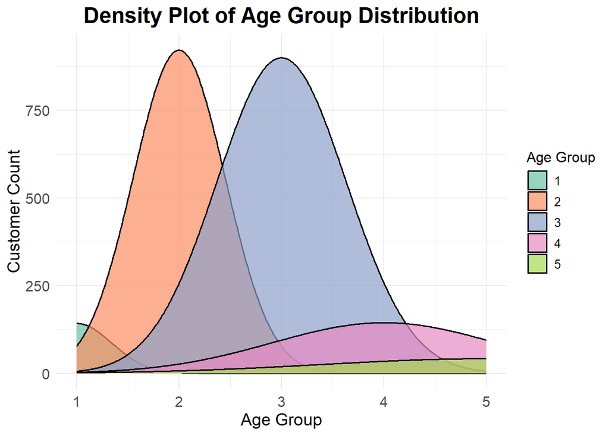

```r
ggplot(customerInfo, aes(x = Age.Group, fill = factor(Age.Group))) +
  geom_density(aes(y = ..count..), alpha = 0.7, color = "black", size = 0.7) +
  scale_fill_brewer(palette = "Set2") +
  labs(
    x = "Age Group",
    y = "Customer Count",
    title = "Density Plot of Age Group Distribution",
    fill = "Age Group"
  ) +
  theme_minimal() +  # Apply a clean, minimal theme
  theme(
    plot.title = element_text(hjust = 0.5, size = 18, face = "bold"),
    axis.title.x = element_text(size = 14),
    axis.title.y = element_text(size = 14),
    axis.text.x = element_text(size = 12),
    axis.text.y = element_text(size = 12),
    legend.position = "right",
    legend.title = element_text(size = 12),
    legend.text = element_text(size = 10)
  )
```

#### *Observation2:*

There are more customer in the middle age group (2 and 3)

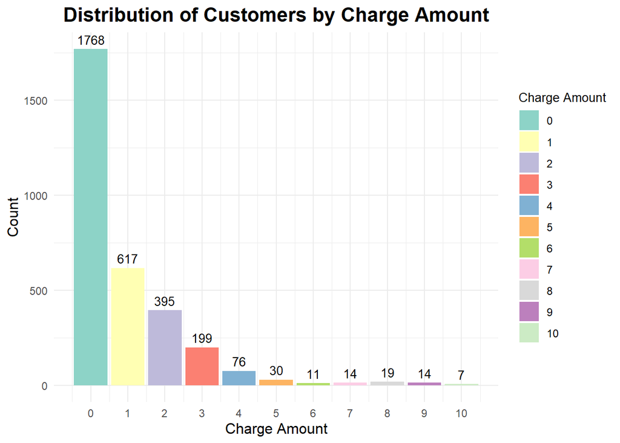

```r
ggplot(customerInfo, aes(x = Charge..Amount, fill = factor(Charge..Amount))) +
  geom_bar() +
  scale_fill_brewer(palette = "Set3") +
  geom_text(stat='count', aes(label=..count..), vjust=-0.5, size=3.5) +
  labs(x = "Charge Amount", y = "Count", fill = "Charge Amount", title = "Distribution of Customers by Charge Amount") +
  scale_x_continuous(breaks = seq(0, max(customerInfo$Charge..Amount), by = 1)) +
  theme_minimal() +
  theme(
    plot.title = element_text(hjust = 0.5, size = 16, face = "bold"),
    axis.title.x = element_text(size = 12),
    axis.title.y = element_text(size = 12),
    legend.position = "right",
    legend.title = element_text(size = 10),
    legend.text = element_text(size = 9)
  )
```

#### Distribution of Churn count across age group

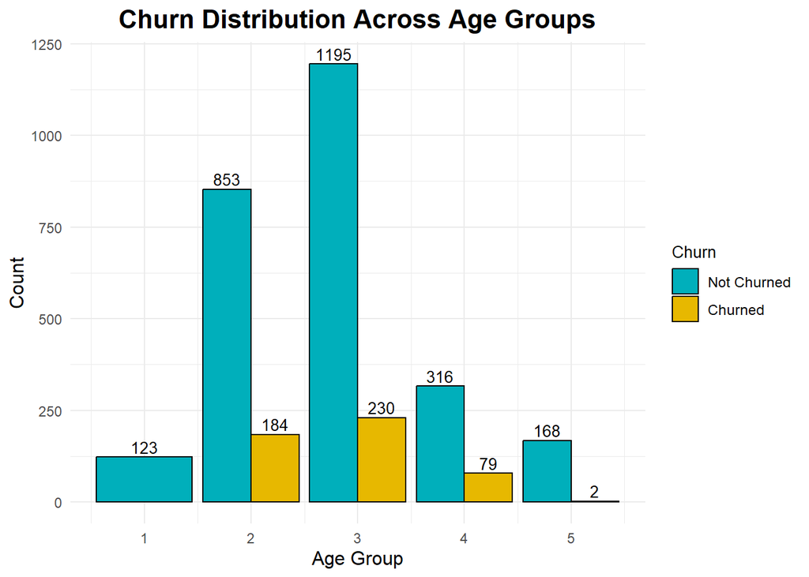

```r
ggplot(customerInfo, aes(x = Age.Group, fill = factor(Churn))) +
  geom_bar(position = "dodge", color = "black") +
  scale_fill_manual(values = c("#00AFBB", "#E7B800"),
                    labels = c("0" = "Not Churned", "1" = "Churned")) +
  geom_text(stat = 'count', aes(label = ..count..), vjust = -0.3, position = position_dodge(0.9), size = 3.5) +
  labs(x = "Age Group", y = "Count", fill = "Churn", title = "Churn Distribution Across Age Groups") +
  theme_minimal() +
  theme(
    plot.title = element_text(hjust = 0.5, size = 16, face = "bold"),
    axis.title.x = element_text(size = 12),
    axis.title.y = element_text(size = 12),
    legend.position = "right",
    legend.title = element_text(size = 10),
    legend.text = element_text(size = 9)
  )
```

#### *Observation 4:*

Customer in the Middle age group(2 and 3) are churned more compared to other age group

#### Distribution of Churn count across status

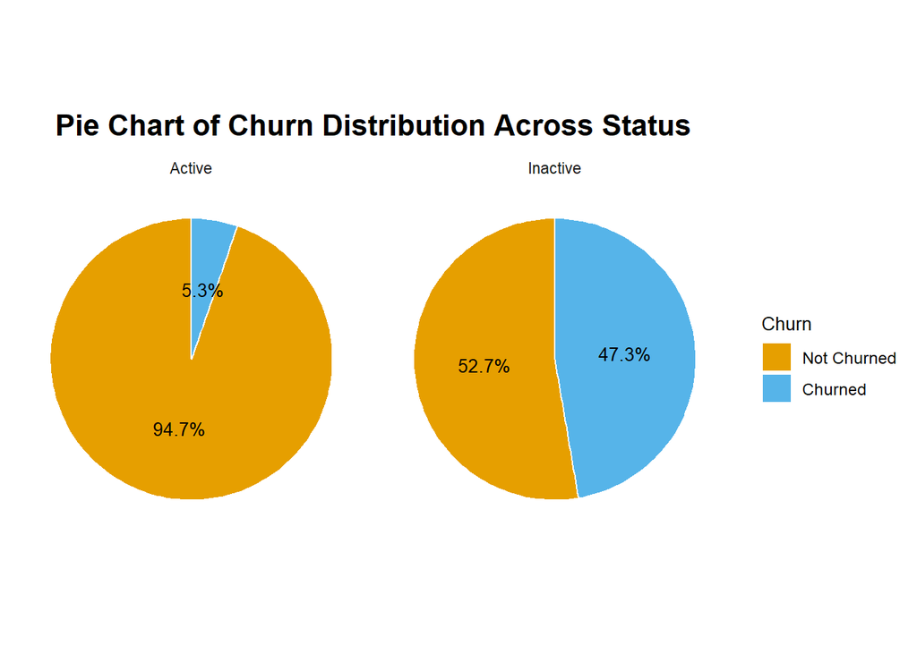

```r
status_churn_table <- table(customerInfo$Status, customerInfo$Churn)
status_churn_df <- as.data.frame(status_churn_table)
colnames(status_churn_df) <- c("Status", "Churn", "Count")
status_churn_pie <- status_churn_df %>%
  group_by(Status) %>%
  mutate(Percentage = Count / sum(Count) * 100)
ggplot(status_churn_pie, aes(x = "", y = Percentage, fill = factor(Churn))) +
  geom_bar(stat = "identity", width = 1, color = "white") +
  coord_polar("y", start = 0) +
  facet_wrap(~Status, ncol = 2, labeller = as_labeller(c(`1` = "Active", `2` = "Inactive"))) +
  labs(x = NULL, y = NULL, fill = "Churn", title = "Pie Chart of Churn Distribution Across Status") +
  scale_fill_manual(values = c("#E69F00", "#56B4E9"), labels = c("Not Churned", "Churned")) +
  theme_minimal() +
  theme(
    plot.title = element_text(hjust = 0.5, size = 16, face = "bold"),
    axis.title.x = element_blank(),
    axis.title.y = element_blank(),
    axis.text = element_blank(),
    legend.position = "right",
    legend.title = element_text(size = 10),
    legend.text = element_text(size = 9),
    panel.grid = element_blank()
  ) +
  geom_text(aes(label = paste0(round(Percentage, 1), "%")),
            position = position_stack(vjust = 0.5), size = 3.5)
```

#### *Observation 5:*

Pie Chart Active and Pie Chart Inactive:  
Pie Chart Active: Churn distribution for “Active” customers.  
Pie Chart Inactive: Churn distribution for “Inactive” customers.  
Inactive customers are more likely to be churned, compared to the Active customers.

#### Pair plot of all features

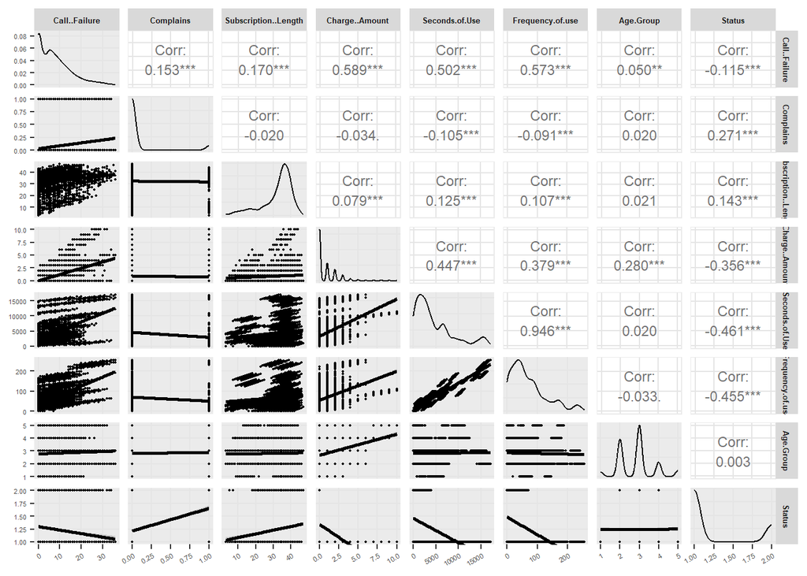

```r
ggpairs(
  customerInfo[,c("Call..Failure", "Complains", "Subscription..Length", "Charge..Amount","Seconds.of.Use","Frequency.of.use","Age.Group", "Status")],
  upper = list(continuous = wrap("cor", size = 3)),
  lower = list(continuous = wrap("smooth", size = 0.3)),
  diag = list(continuous = wrap("densityDiag", alpha = 0.5)),
  axisLabels = "show"
) +
  theme(
    axis.text.x = element_text(angle = 30, hjust = 1, size = 4),
    axis.text.y = element_text(size = 4),
    panel.grid.minor = element_blank(),
    panel.grid.major = element_line(color = "gray90"),
    strip.text = element_text(size = 5, face = "bold")
  )
```

#### *Observation 6:*

Frequency_of_use and seconds_of_use is strongly correlated.

#### Using correlation matrix to find the correlation

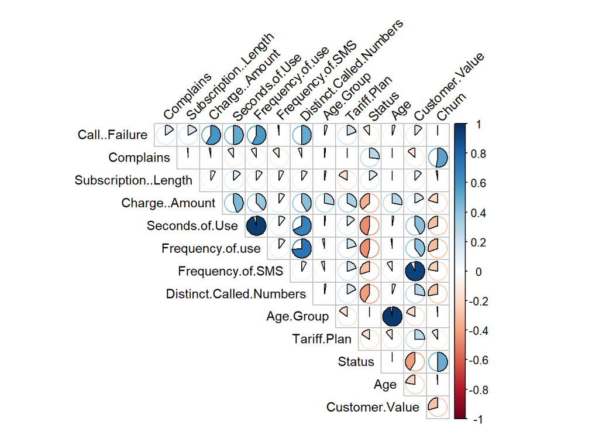

```r
cor_matrix <- cor(customerInfo)
corrplot(
  cor_matrix,
  method = "pie",
  type = "upper",
  tl.col = "black",
  tl.srt = 45,
  tl.cex = 0.9,
  cl.cex = 0.8,
  number.cex = 0.7,
  pie.cex = 1.2,
  mar = c(0, 0, 1, 0),
  diag = FALSE
)
```

#### *Observation 7:*

There is a strong positive correlation with Frequency_of_use and Seconds_of_use There is a positive correlation between complains and customer Churn

#### Dropping the correlated columns to avoid collinearity Dropping Age column, as `Age` and `Age.Group` represent same feature.

```r
customerInfo <- customerInfo %>% select(-c(Frequency.of.use,Age))
```

### **Scaling Continuous Variable**

```r
customerInfo_int <- customerInfo[,-c(2,8,9,10,12)]
customerInfo_int <- data.frame(scale(customerInfo_int))
```

### **Creating factors for Categorical Data**

```r
customerInfo$Complains <- factor(customerInfo$Complains)
customerInfo$Age.Group <- factor(customerInfo$Age.Group)
customerInfo$Tariff.Plan <- factor(customerInfo$Tariff.Plan)
customerInfo$Status <- factor(customerInfo$Status)
customerInfo$Age.Group <- factor(customerInfo$Age.Group)
customerInfo_scaled <- customerInfo %>%
                  select(c(2,8,9,10,12)) %>%
                  cbind(customerInfo_int)
```

### **Creating Dummy variable for Categorical Data**

```r
sparse_matrix <- model.matrix(Churn ~ ., data = customerInfo_scaled)[,-1]
customerInfo_final <-  customerInfo_scaled %>% select(c("Churn")) %>% cbind(sparse_matrix)
```

### **Split Train and Test Data**

```r
target <- "Churn"
features <- setdiff(names(customerInfo_final), target)
set.seed(123)
trainIndex <- createDataPartition(customerInfo_final[[target]], p = 0.8,
                                  list = FALSE,
                                  times = 1)
dataTrain <- customerInfo_final[trainIndex, ]
dataTest <- customerInfo_final[-trainIndex, ]
xTrain <- dataTrain[, features]
yTrain <- dataTrain[[target]]
xTest <- dataTest[, features]
yTest <- dataTest[[target]]
```

### **Put our testing & training data into two separates Dmatrixs objects**

```r
dtrain <- xgb.DMatrix(data = as.matrix(xTrain), label= yTrain)
dtest <- xgb.DMatrix(data = as.matrix(xTest), label= yTest)
```

## **Logistic regression**

```r
logistic_model <- glm(Churn ~ ., data = dataTrain, family = "binomial")
logistic_predict_test <- predict(logistic_model , xTest, type = "response")
predictions_Logistic <- data.frame(actual = yTest,
                          predicted = ifelse(logistic_predict_test > 0.5, 1, 0))
confusionMatrix(as.factor(predictions_Logistic$predicted), as.factor(yTest),positive = "1",  mode = "everything")
```

```
## Confusion Matrix and Statistics
##
##           Reference
## Prediction   0   1
##          0 509  56
##          1  15  50
##
##                Accuracy : 0.8873
##                  95% CI : (0.86, 0.9109)
##     No Information Rate : 0.8317
##     P-Value [Acc > NIR] : 5.919e-05
##
##                   Kappa : 0.5239
##
##  Mcnemar's Test P-Value : 2.063e-06
##
##             Sensitivity : 0.47170
##             Specificity : 0.97137
##          Pos Pred Value : 0.76923
##          Neg Pred Value : 0.90088
##               Precision : 0.76923
##                  Recall : 0.47170
##                      F1 : 0.58480
##              Prevalence : 0.16825
##          Detection Rate : 0.07937
##    Detection Prevalence : 0.10317
##       Balanced Accuracy : 0.72154
##
##        'Positive' Class : 1
##
```

### **Running with default params**

```r
default_param<-list(
        objective = "binary:logistic",
        eval_metric = "logloss",
        eta=0.3, #default = 0.3
        gamma=0,
        max_depth=6, #default=6
        min_child_weight=1, #default=1
        subsample=1,
        colsample_bytree=1)

xgbcv <- xgb.cv( params = default_param, data = dtrain, nrounds = 500, nfold = 5, showsd = T, stratified = T, print_every_n = 40, early_stopping_rounds = 10, maximize = F)
```

[output not shown]

```r
xgb_mod <- xgb.train(data = dtrain, params=default_param, nrounds = 38)
preds_def <- predict(xgb_mod, dtest)
predictions_def_XGB <- data.frame(actual = yTest,
                          predicted = ifelse(preds_def > 0.5, 1, 0))
confusionMatrix(as.factor(predictions_def_XGB$predicted), as.factor(yTest),positive = "1",  mode = "everything")
```

```
## Confusion Matrix and Statistics
##
##           Reference
## Prediction   0   1
##          0 511  16
##          1  13  90
##
##                Accuracy : 0.954
##                  95% CI : (0.9346, 0.969)
##     No Information Rate : 0.8317
##     P-Value [Acc > NIR] : <2e-16
##
##                   Kappa : 0.8337
##
##  Mcnemar's Test P-Value : 0.7103
##
##             Sensitivity : 0.8491
##             Specificity : 0.9752
##          Pos Pred Value : 0.8738
##          Neg Pred Value : 0.9696
##               Precision : 0.8738
##                  Recall : 0.8491
##                      F1 : 0.8612
##              Prevalence : 0.1683
##          Detection Rate : 0.1429
##    Detection Prevalence : 0.1635
##       Balanced Accuracy : 0.9121
##
##        'Positive' Class : 1
##
```

### **Setting up a grid that tunes both these parameters, and also the ETA (learning rate).**

```r
xgb_grid = expand.grid(
nrounds = 1000,
eta = c(0.1, 0.05, 0.03),
max_depth = c(2, 3, 4),
gamma = 0,
colsample_bytree=1,
min_child_weight=c(1, 2, 3),
subsample=1
)
```

```r
set.seed(27042018)
my_control <-trainControl(method="cv", number=5)
#xgb_caret <- train(x=xTrain, y=yTrain, method='xgbTree', trControl= my_control, tuneGrid=xgb_grid)
#xgb_caret$bestTune
```

### **Forming the Params based on the best tune**

```r
best_tune_param<-list(
        objective = "binary:logistic",
        eval_metric = "logloss",
        eta=0.05, #default = 0.3
        gamma=0,
        max_depth=4, #default=6
        min_child_weight=3, #default=1
        subsample=1,
        colsample_bytree=1
)
```

### **Cross validation to determine the best number of rounds (for the given set of parameters).**

```r
xgbcv <- xgb.cv( params = best_tune_param, data = dtrain, nrounds = 700, nfold = 5, showsd = T, stratified = T, print_every_n = 40, early_stopping_rounds = 10, maximize = F)
```

[output not shown]

```r
xgb_mod <- xgb.train(data = dtrain, params=best_tune_param, nrounds = 352)
```

```r
preds <- predict(xgb_mod, dtest)
predictions_XGB <- data.frame(actual = yTest,
                          predicted = ifelse(preds > 0.3, 1, 0))
head(predictions_XGB)
```

```
##   actual predicted
## 1      0         0
## 2      0         0
## 3      0         0
## 4      0         0
## 5      0         0
## 6      1         0
```

## **Confusion matrix for the predictions**

```r
confusionMatrix(as.factor(predictions_XGB$predicted), as.factor(yTest),positive = "1", mode = "everything")
```

```
## Confusion Matrix and Statistics
##
##           Reference
## Prediction   0   1
##          0 505  13
##          1  19  93
##
##                Accuracy : 0.9492
##                  95% CI : (0.929, 0.965)
##     No Information Rate : 0.8317
##     P-Value [Acc > NIR] : <2e-16
##
##                   Kappa : 0.8225
##
##  Mcnemar's Test P-Value : 0.3768
##
##             Sensitivity : 0.8774
##             Specificity : 0.9637
##          Pos Pred Value : 0.8304
##          Neg Pred Value : 0.9749
##               Precision : 0.8304
##                  Recall : 0.8774
##                      F1 : 0.8532
##              Prevalence : 0.1683
##          Detection Rate : 0.1476
##    Detection Prevalence : 0.1778
##       Balanced Accuracy : 0.9205
##
##        'Positive' Class : 1
##
```

### **Plotting the roc curve**

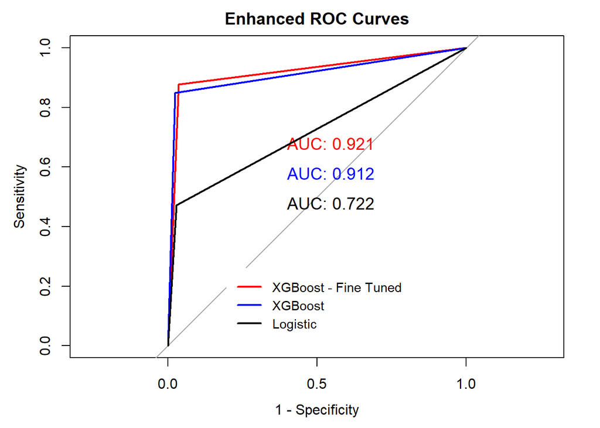

```r
plot.roc(yTest, as.numeric(predictions_XGB$predicted),
         print.auc = TRUE,
         col = 'red',
         lwd = 2,
         main = "Enhanced ROC Curves",
         legacy.axes = TRUE,
         print.auc.y = 0.7,
         print.auc.x = 0.6,
         print.auc.cex = 1.2)
plot.roc(yTest, as.numeric(predictions_def_XGB$predicted),
         print.auc = TRUE,
         col = 'blue',
         lwd = 2,
         add = TRUE,
         print.auc.y = 0.6,
         print.auc.x = 0.6,
         print.auc.cex = 1.2)
plot.roc(yTest, as.numeric(predictions_Logistic$predicted),
         print.auc = TRUE,
         col = 'black',
         lwd = 2,
         add = TRUE,
         print.auc.y = 0.5,
         print.auc.x = 0.6,
         print.auc.cex = 1.2)
legend("bottom",
       legend = c("XGBoost - Fine Tuned", "XGBoost", "Logistic"),
       lty = c(1, 1),
       lwd = c(2, 2, 2),
       col = c("red", "blue", "black"),
       cex = 0.9,
       box.lty = 0,
       inset = 0.05)
```

## *Feature Importance*

SHAP Feature Importance

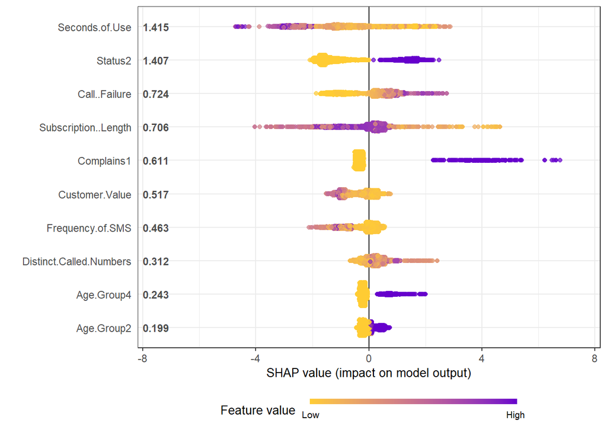

```r
shap.plot.summary.wrap1(xgb_mod, as.matrix(xTrain), top_n = 10)
```

### Distribution of Churn count across Complains

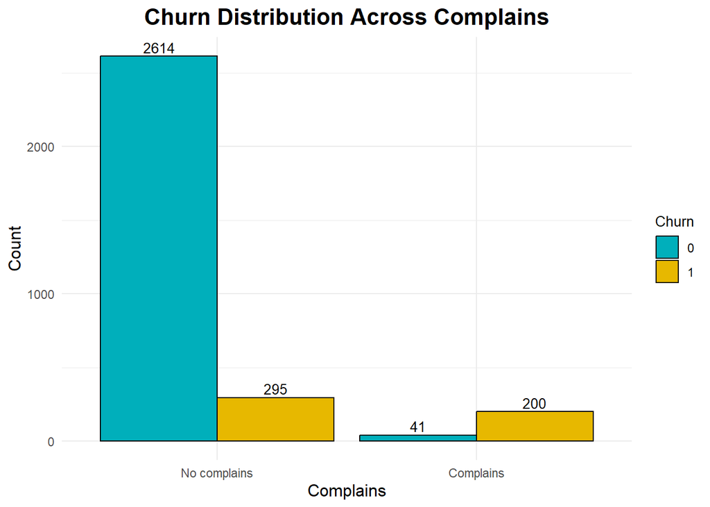

```r
ggplot(customerInfo, aes(x = Complains, fill = factor(Churn))) +
  geom_bar(position = "dodge", color = "black") +  # Grouped bar plot with black border
  scale_fill_manual(values = c("#00AFBB", "#E7B800")) +  # Custom colors for the Churn groups
  scale_x_discrete(labels = c("0" = "No complains", "1" = "Complains")) +
  geom_text(stat = 'count', aes(label = ..count..), vjust = -0.3, position = position_dodge(0.9), size = 3.5) +  # Adding count labels
  labs(x = "Complains", y = "Count", fill = "Churn", title = "Churn Distribution Across Complains") +
  theme_minimal() +  # Apply a minimalistic theme
  theme(
    plot.title = element_text(hjust = 0.5, size = 16, face = "bold"),  # Center and bold the title
    axis.title.x = element_text(size = 12),
    axis.title.y = element_text(size = 12),
    legend.position = "right",  # Position the legend on the right
    legend.title = element_text(size = 10),
    legend.text = element_text(size = 9)
  )
```

### Distribution of Churn count across Seconds.of.use

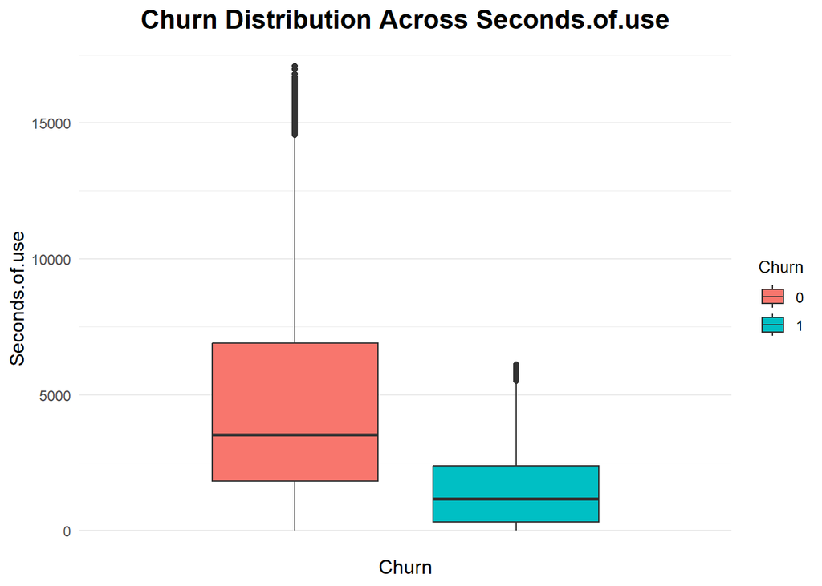

```r
ggplot(customerInfo, aes(x = Churn, y = Seconds.of.Use, fill = factor(Churn))) +
  geom_boxplot() +
  scale_x_discrete(labels = c("0" = "Not Churned", "1" = "Churned")) +
  labs(x = "Churn", y = "Seconds.of.use", fill = "Churn", title = "Churn Distribution Across Seconds.of.use") +
  theme_minimal() +  # Apply a minimalistic theme
  theme(
    plot.title = element_text(hjust = 0.5, size = 16, face = "bold"),  # Center and bold the title
    axis.title.x = element_text(size = 12),
    axis.title.y = element_text(size = 12),
    legend.position = "right",  # Position the legend on the right
    legend.title = element_text(size = 10),
    legend.text = element_text(size = 9)
  )
```

## *Final Observation*

From Model Inactive Customers (Status) are most likely to be churned. Customers who use for less seconds are likely to be churned. Customers who raised Complaints are churned compared to customers with no complaints.